# Rbiips example: Switching stochastic volatility

In this example, we consider the Markov switching stochastic volatility model.

Reference: C.M. Carvalho and H.F. Lopes. Simulation-based sequential analysis of Markov switching stochastic volatility models. Computational Statistics and Data analysis (2007) 4526-4542.

# Statistical model

Let $y_t$ be the response variable and $x_t$ the unobserved log-volatility of $y_t$. The stochastic volatility model is defined as follows for $t\leq t_{max}$

$x_t|(x_{t-1},\alpha,\phi,\sigma,c_t) \sim \mathcal N (\alpha_{c_t} + \phi x_{t-1} , \sigma^2)$

$y_t|x_t \sim \mathcal N (0, \exp(x_t))$

The regime variables $c_t$ follow a two-state Markov process with transition probabilities

$p_{ij}=Pr(c_t=j|c_{t-1}=i)$

$\mathcal N(m,\sigma^2)$ denotes the normal distribution of mean $m$ and variance $\sigma^2$.

# Statistical model in BUGS language

Content of the file `'switch_stoch_volatility.bug'`:

```r
model_file = 'switch_stoch_volatility.bug' # BUGS model filename
cat(readLines(model_file), sep = "\n")
```

```
var y[t_max],x[t_max],mu[t_max],mu_true[t_max],c[t_max],c_true[t_max]
data
{
  c_true[1] ~ dcat(pi[c0,])
  mu_true[1] <- alpha[1] * (c_true[1]==1) + alpha[2]*(c_true[1]==2) + phi*x0
  x_true[1] ~ dnorm(mu_true[1], 1/sigma^2)
  y[1] ~ dnorm(0, exp(-x_true[1]))
  for (t in 2:t_max)
  {
    c_true[t] ~ dcat(ifelse(c_true[t-1]==1,pi[1,],pi[2,]))
    mu_true[t] <- alpha[1]*(c_true[t]==1) + alpha[2]*(c_true[t]==2) + phi*x_true[t-1];
    x_true[t] ~ dnorm(mu_true[t], 1/sigma^2)
    y[t] ~ dnorm(0, exp(-x_true[t]))
  }
}

model
{
  c[1] ~ dcat(pi[c0,])
  mu[1] <- alpha[1] * (c[1]==1) + alpha[2]*(c[1]==2)+ phi*x0
  x[1] ~ dnorm(mu[1], 1/sigma^2)
  y[1] ~ dnorm(0, exp(-x[1]))
  for (t in 2:t_max)
  {
    c[t] ~ dcat(ifelse(c[t-1]==1, pi[1,], pi[2,]))
    mu[t] <- alpha[1] * (c[t]==1) + alpha[2]*(c[t]==2) + phi*x[t-1]
    x[t] ~ dnorm(mu[t], 1/sigma^2)
    y[t] ~ dnorm(0, exp(-x[t]))
  }
}
```

# Installation of Rbiips package

1. [Download](https://alea.bordeaux.inria.fr/biips/doku.php?id=download) the latest version of Rbiips package depending on your system:
   - `Rbiips_x.x.x.zip` for Windows
   - `Rbiips_x.x.x.tgz` for Mac OS X
   - `Rbiips_x.x.x.tar.gz` for Linux

   where `x.x.x` is the version of the package and `ext` is the archive extension for your system.
2. Install the package from R

```r
install.packages('path/to/Rbiips_x.x.x.ext', repos=NULL)
```

3. Load Rbiips package

```r
require(Rbiips)
```

**Note:** Linux installation needs a previous installation of Biips libraries and headers as well as Boost.

# General settings

```r
par(bty='l')
light_blue = rgb(.7, .7, 1)
light_red = rgb(1, .7, .7)
hot_colors = colorRampPalette(c('black', 'red', 'yellow', 'white'))
```

Set the random numbers generator seed for reproducibility

```r
set.seed(0)
```

# Load model and data

#### Model parameters

```r
sigma = .4; alpha = c(-2.5, -1); phi = .5; c0 = 1; x0 = 0; t_max = 100
pi = matrix(c(.9, .1, .1, .9), nrow=2, byrow=TRUE)
data = list(t_max=t_max, sigma=sigma,
            alpha=alpha, phi=phi, pi=pi, c0=c0, x0=x0)
```

#### Parse and compile BUGS model, and sample data

```r
model = biips_model(model_file, data, sample_data=TRUE)
```

```
* Parsing model in: switch_stoch_volatility.bug
* Compiling data graph
  Declaring variables
  Graph size: 1215
  Sampling data
  Reading data back into data table
  Declaring variables
  Graph size: 1218
```

```r
data = model$data()
```

Plot the data

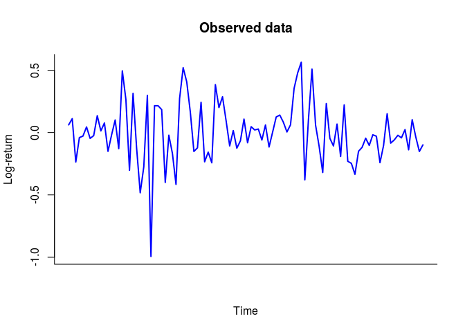

```r
plot(1:t_max, data$y, type='l', col='blue', lwd=2,
     main='Observed data',
     xlab='Time', ylab='Log-return', xaxt = 'n')
```

# Biips Sequential Monte Carlo

#### Run SMC

```r
n_part = 5000 # Number of particles
variables = c('x') # Variables to be monitored
out_smc = biips_smc_samples(model, variables, n_part)
```

```
* Assigning node samplers
* Running SMC forward sampler with 5000 particles
  |**************************************************| 100 iterations in 7.70 s
```

#### Diagnosis of the algorithm

```r
diag_smc = biips_diagnosis(out_smc)
```

```
* Diagnosis of variable: x[1:100]
  Filtering: GOOD
  Smoothing: GOOD
```

#### Plot Smoothing ESS

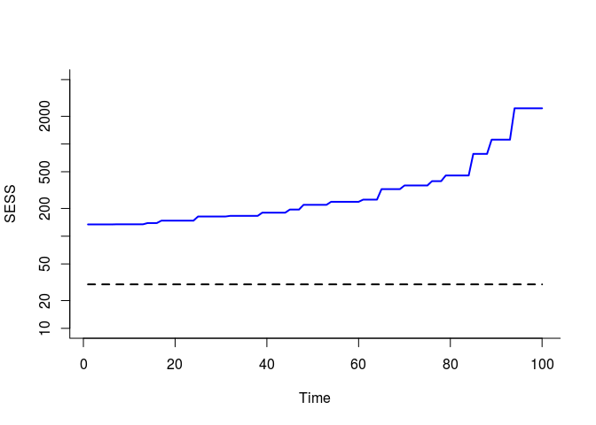

```r
plot(out_smc$x$s$ess, type='l', log='y', col='blue', lwd=2,
     xlab='Time', ylab='SESS',
     ylim=c(10, n_part))
lines(1:t_max, rep(30,t_max), lwd=2, lty=2)
```

#### Plot weighted particles

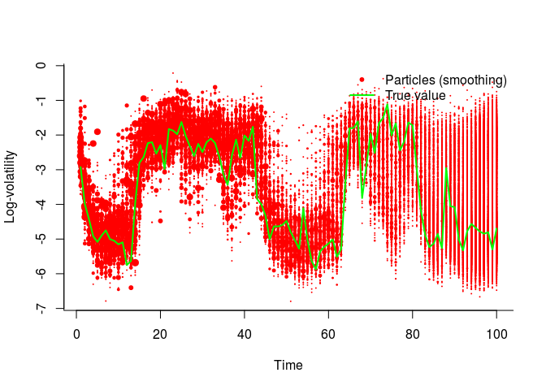

```r
matplot(1:t_max, out_smc$x$s$values, type='n',
        xlab='Time', ylab='Log-volatility')
for (t in 1:t_max) {
  val = unique(out_smc$x$s$values[t,])
  weight = sapply(val, FUN=function(x) {
    ind = out_smc$x$s$values[t,] == x
    return(sum(out_smc$x$s$weights[t,ind]))
  })
  points(rep(t, length(val)), val, col='red', pch=20,
         cex=sapply(weight, FUN=function(x) {min(2, .02*n_part*x)}))
}
lines(1:t_max, data$x_true, col='green', lwd=2)
legend('topright', leg=c('Particles (smoothing)', 'True value'),
       col=c('red','green'), lwd=c(NA,2), pch=c(20,NA),
       bty='n')
```

#### Summary statistics

```r
summ_smc = biips_summary(out_smc, probs=c(.025, .975))
```

#### Plot Filtering estimates

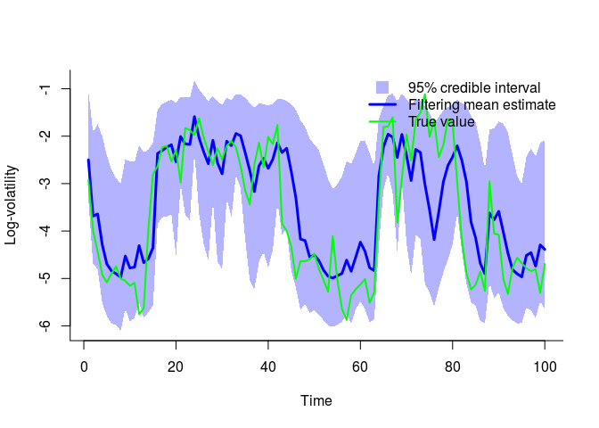

```r
x_f_mean = summ_smc$x$f$mean
x_f_quant = summ_smc$x$f$quant

xx = c(1:t_max, t_max:1)
yy = c(x_f_quant[[1]], rev(x_f_quant[[2]]))
plot(xx, yy, type='n', xlab='Time', ylab='Log-volatility')

polygon(xx, yy, col=light_blue, border=NA)
lines(1:t_max, x_f_mean, col='blue', lwd=3)
lines(1:t_max, data$x_true, col='green', lwd=2)
legend('topright', leg=c('95% credible interval', 'Filtering mean estimate', 'True value'),
       col=c(light_blue,'blue','green'), lwd=c(NA,3,2), pch=c(15,NA,NA), pt.cex=c(2,1,1),
       bty='n')
```

#### Plot Smoothing estimates

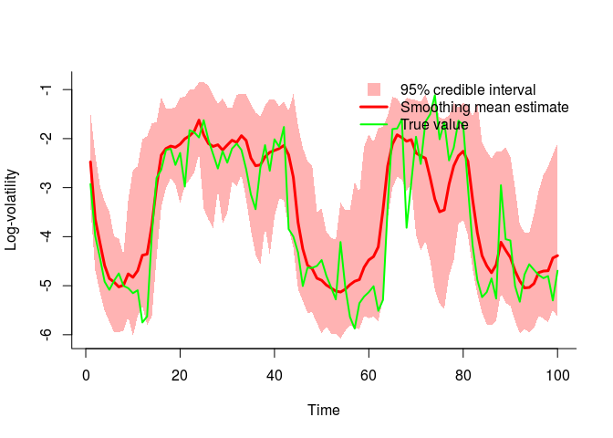

```r
x_s_mean = summ_smc$x$s$mean
x_s_quant = summ_smc$x$s$quant

xx = c(1:t_max, t_max:1)
yy = c(x_s_quant[[1]], rev(x_s_quant[[2]]))
plot(xx, yy, type='n', xlab='Time', ylab='Log-volatility')

polygon(xx, yy, col=light_red, border=NA)
lines(1:t_max, x_s_mean, col='red', lwd=3)
lines(1:t_max, data$x_true, col='green', lwd=2)
legend('topright', leg=c('95% credible interval', 'Smoothing mean estimate', 'True value'),
       col=c(light_red,'red','green'), lwd=c(NA,3,2), pch=c(15,NA,NA), pt.cex=c(2,1,1),
       bty='n')
```

#### Marginal filtering and smoothing densities

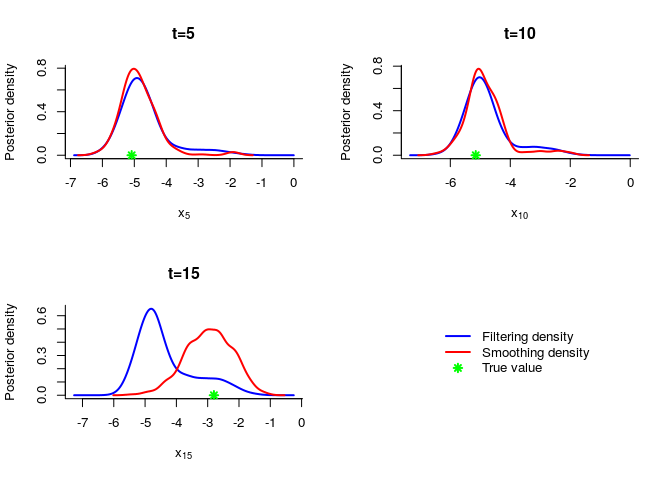

```r
kde_smc = biips_density(out_smc)
time_index = c(5, 10, 15)
par(mfrow=c(2,2))
for (k in 1:length(time_index)) {
  tk = time_index[k]
  plot(kde_smc$x[[tk]], col=c('blue', 'red'), lwd=2,
       xlab=bquote(x[.(tk)]), ylab='Posterior density',
       main=paste('t=', tk, sep=''))
  points(data$x_true[tk], 0, col='green', pch=8, lwd=2)
}
plot(0, type='n', bty='n', xaxt='n', yaxt='n', xlab="", ylab="")
legend('center', leg=c('Filtering density', 'Smoothing density', 'True value'),
       col=c('blue', 'red', 'green'), pch=c(NA,NA,8), lty=c(1,1,NA), lwd=2,
       bty='n')
par(mfrow=c(1,1))
```

# Biips Particle Independent Metropolis-Hastings

#### Parameters of the PIMH

```r
n_burn = 2000
n_iter = 10000
thin = 1
n_part = 50
```

#### Run PIMH

```r
obj_pimh = biips_pimh_init(model, variables)
```

```
* Initializing PIMH
```

```r
biips_pimh_update(obj_pimh, n_burn, n_part) # Burn-in iterations
```

```
* Updating PIMH with 50 particles
  |**************************************************| 2000 iterations in 117.63 s
```

```r
out_pimh = biips_pimh_samples(obj_pimh, n_iter, n_part, thin=thin) # Return samples
```

```
* Generating PIMH samples with 50 particles
  |**************************************************| 10000 iterations in 597.86 s
```

#### Some summary statistics

```r
summ_pimh = biips_summary(out_pimh, probs=c(.025, .975))
```

#### Posterior mean and quantiles

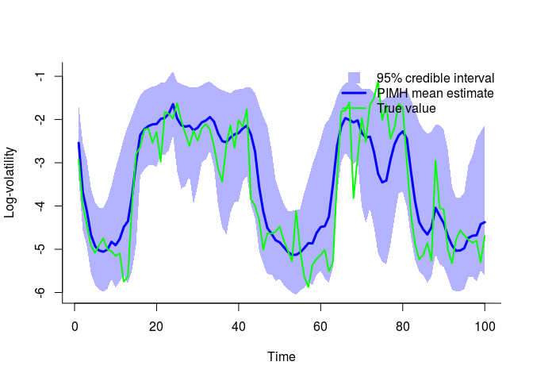

```r
x_pimh_mean = summ_pimh$x$mean
x_pimh_quant = summ_pimh$x$quant

xx = c(1:t_max, t_max:1)
yy = c(x_pimh_quant[[1]], rev(x_pimh_quant[[2]]))
plot(xx, yy, type='n', xlab='Time', ylab='Log-volatility')

polygon(xx, yy, col=light_blue, border=NA)
lines(1:t_max, x_pimh_mean, col='blue', lwd=3)
lines(1:t_max, data$x_true, col='green', lwd=2)
legend('topright', leg=c('95% credible interval', 'PIMH mean estimate', 'True value'),
       col=c(light_blue,'blue','green'), lwd=c(NA,3,2), pch=c(15,NA,NA), pt.cex=c(2,1,1),
       bty='n')
```

#### Trace of MCMC samples

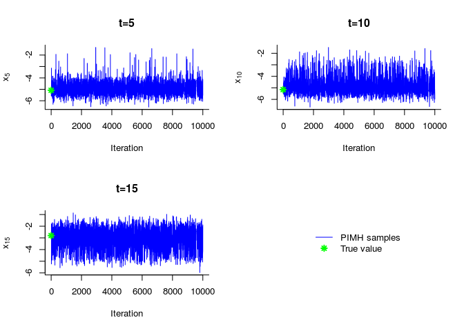

```r
time_index = c(5, 10, 15)
par(mfrow=c(2,2))
for (k in 1:length(time_index)) {
  tk = time_index[k]
  plot(out_pimh$x[tk,], col='blue', type='l',
       xlab='Iteration', ylab=bquote(x[.(tk)]),
       main=paste('t=', tk, sep=''))
  points(0, data$x_true[tk], col='green', pch=8, lwd=2)
}
plot(0, type='n', bty='n', xaxt='n', yaxt='n', xlab="", ylab="")
legend('center', leg=c('PIMH samples', 'True value'),
       col=c('blue', 'green'), pch=c(NA,8), lwd=c(1,2), lty=c(1,NA),
       bty='n')
```

#### Histograms of posteriors

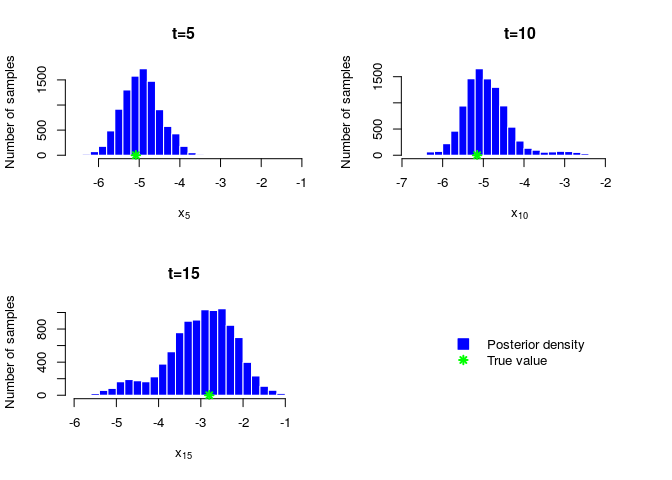

```r
par(mfrow=c(2,2))
for (k in 1:length(time_index)) {
  tk = time_index[k]
  hist(out_pimh$x[tk,], breaks=20, col='blue', border='white',
       xlab=bquote(x[.(tk)]), ylab='Number of samples',
       main=paste('t=', tk, sep=''))
  points(data$x_true[tk], 0, col='green', pch=8, lwd=2)
}
plot(0, type='n', bty='n', xaxt='n', yaxt='n', xlab="", ylab="")
legend('center', leg=c('Posterior density', 'True value'),
       col=c('blue', 'green'), pch=c(22,8), lwd=c(NA,2), lty=NA, pt.cex=c(2,1), pt.bg=c(4,NA),
       bty='n')
```

#### Kernel density estimates of posteriors

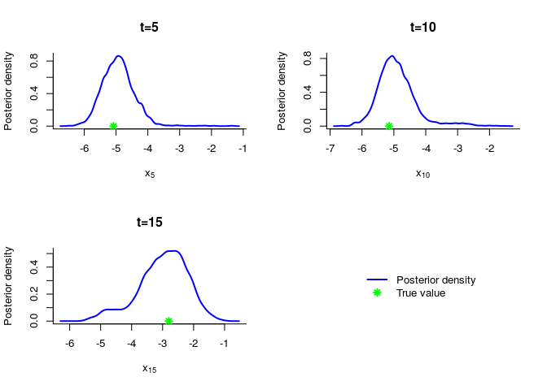

```r
par(mfrow=c(2,2))
for (k in 1:length(time_index)) {
  tk = time_index[k]
  kde_pimh = density(out_pimh$x[tk,])
  plot(kde_pimh, col='blue', lwd=2,
       xlab=bquote(x[.(tk)]), ylab='Posterior density',
       main=paste('t=', tk, sep=''))
  points(data$x_true[tk], 0, col='green', pch=8, lwd=2)
}
plot(0, type='n', bty='n', xaxt='n', yaxt='n', xlab="", ylab="")
legend('center', leg=c('Posterior density', 'True value'),
       col=c('blue', 'green'), pch=c(NA,8), lwd=2, lty=c(1,NA),
       bty='n')
par(mfrow=c(1,1))
```

# Biips Sensitivity analysis

We want to study sensitivity to the values of the parameter $\alpha$

#### Parameters of the algorithm

```r
n_part = 50 # Number of particles
range <- seq(-5,2,.2) # Range of values for one component
A = rep(range, times=length(range)) # Values of the first component
B = rep(range, each=length(range)) # Values of the second component
param_values = list('alpha' = rbind(A, B))
```

#### Run sensitivity analysis with SMC

```r
out_sens = biips_smc_sensitivity(model, param_values, n_part)
```

```
* Analyzing sensitivity with 50 particles
  |**************************************************| 1296 iterations in 72.64 s
```

```r
# Avoid scaling problems by thresholding the values
thres = -40
zz = matrix(pmax(thres, out_sens$log_marg_like), nrow=length(range))

require(lattice)
```

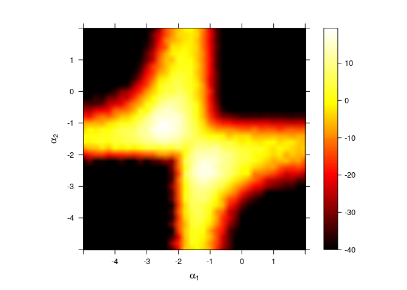

```r
levelplot(zz, row.values=range, column.values=range, bg='black',
          at=seq(thres, max(zz), len=100), col.regions=hot_colors(100),
          xlim=c(-5,2), ylim=c(-5,2),
          xlab=expression(alpha[1]), ylab=expression(alpha[2]),
          interpolate=TRUE, useRaster=TRUE, bty='l')
```